# Walinchus Astronomy

David H. Montgomery

10/19/2020

```r
knitr::opts_chunk$set(echo = TRUE, warning = FALSE, message = FALSE)
library(tidyverse)
library(scales)
library(ggforce)
library(ggrepel)
```

## Load our data

The first step is to always load your data in, and clean up any messy bits

```r
# Load the data
space_data <- read_csv("https://raw.githubusercontent.com/dhmontgomery/walinchus-astronomy/master/space_data.csv") %>%
    janitor::clean_names() %>% # Run a function to clean up the column names
    mutate(across(-object, as.numeric)) %>% # Convert everything to numeric
    filter(!is.na(distance_from_sun_million_km)) %>% # Remove missing data
    mutate(object = str_remove_all(object, "\\(an asteroid\\)")) # Remove "(an asteroid)" from Ceres' name
```

## Create a quick graph: distance from the Sun

The first thing I always like to do is make a quick, ugly chart to see what the data looks like.

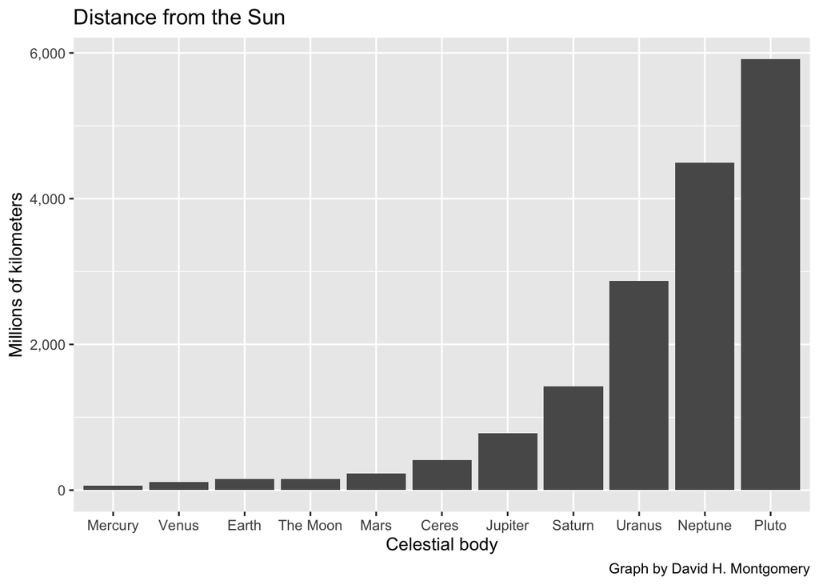

```r
# Format the data
space_data %>% # Start with our data
    # Create the graph
    ggplot(aes(x = fct_reorder(object, distance_from_sun_million_km), # Set X as the object names, ordered by distance
               y = distance_from_sun_million_km)) + # Set Y as the distance
    geom_col() + # Make it a column graph
    scale_y_continuous(labels = comma) + # Format the y-axis text
    # Set chart labels
    labs(title = "Distance from the Sun", # Title
         y = "Millions of kilometers", # Y-axis title
         x = "Celestial body", # X-axis title
         caption = "Graph by David H. Montgomery") # Caption
```

```r
ggsave("distance_from_the_sun.png", width = 8, height = 6) # Save to disk
```

## Make our graph prettier

Once I’ve done that, I customioze the chart to make it look nicer — something I might want to publish.

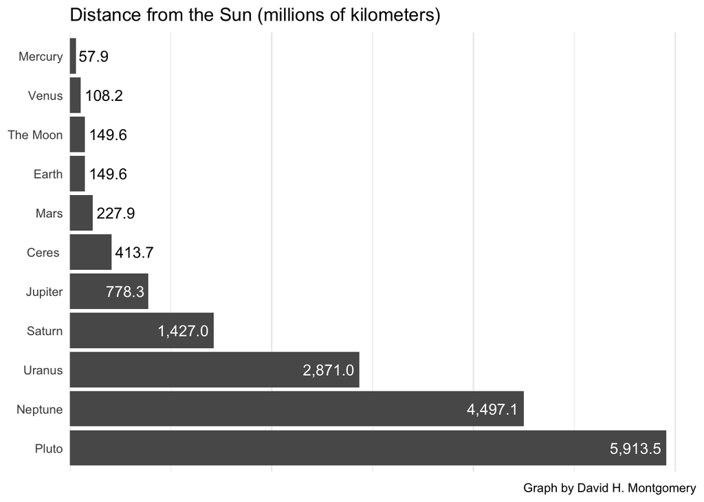

```r
# Format the data
space_data %>% # Start with our data
    # Create the graph
    ggplot(aes(x = fct_reorder(object, distance_from_sun_million_km, .desc = TRUE), # Set X as the object names, ordered by distance
               y = distance_from_sun_million_km)) + # Set Y as the distance
    geom_col() + # Make it a column graph
    # Add direct labels
    geom_text(aes(label = comma(distance_from_sun_million_km, accuracy = .1), # Set the label text
                  # Set a different position for large and small values
                  hjust = case_when(distance_from_sun_million_km < 500 ~ -.1, TRUE ~ 1.1),
                  # Set a different color for large and small values
                  color = case_when(distance_from_sun_million_km < 500 ~ "black", TRUE ~ "white"))) +
    scale_y_continuous(labels = comma, expand = expansion(mult = c(0, 0.05))) + # Format scale
    scale_color_identity() + # Tell R to treat "white" and "black" as actual colors
    coord_flip() + # Rotate the chart 90º
    # Set chart labels
    labs(title = "Distance from the Sun (millions of kilometers)",
         y = "Millions of kilometers",
         x = "Celestial body",
         caption = "Graph by David H. Montgomery") +
    theme_minimal() + # Set a theme
    # Customize theme
    theme(axis.title = element_blank(), # Hide axis titles
          axis.text.x = element_blank(), # Hide x-axis labels
          # Hide vertical griddlines
          panel.grid.major.y = element_blank(),
          panel.grid.minor.y = element_blank())
```

```r
ggsave("distance_from_the_sun_pretty.png", width = 8, height = 6) # Save to disk
```

## Make a complicated graph, showing distance as orbits

I often experiment with different ways of visualizing the data. The below chart takes the same data as above — each celestial object’s distance from the Sun — and portrays it with approximations of orbits, a possibly more intuitive way to understand the data.

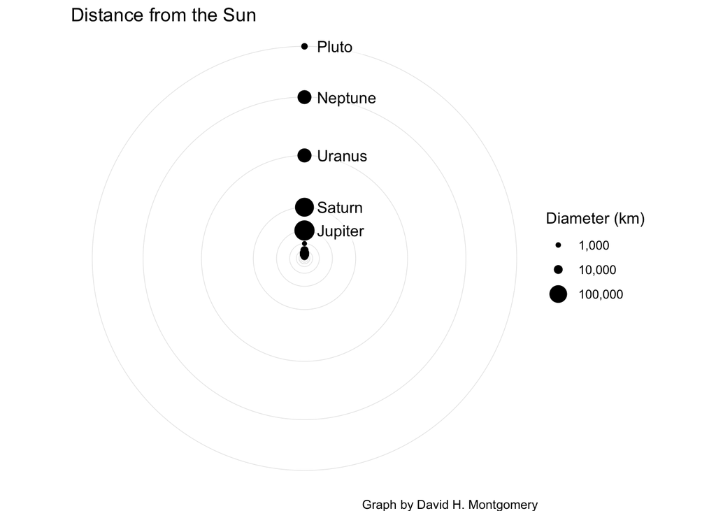

```r
space_data %>% # Start with our data
    ggplot() + # Start graph
    geom_circle(aes(x0 = 0, y0 = 0, # Set our origin to (0, 0)
                    r = distance_from_sun_million_km), # Use distance as our radius
                size = .2, color = "grey90") + # Set size and color of lines
    geom_point(aes(x = 0, y = distance_from_sun_million_km, # Add points
                   size = diameter_km)) + # Govern dot size by diameter
    # Add blank labels as a background (hacky workaround to make this look better)
    geom_label(data = . %>% filter(distance_from_sun_million_km > 500), aes(x = 0, y = distance_from_sun_million_km, label = object), hjust = 0, nudge_x = 350, color = NA, alpha = .5) +
    # Add text labels
    geom_text(data = . %>% filter(distance_from_sun_million_km > 500), # Filter out inner planets
              aes(x = 0, # x-axis position to 0
                y = distance_from_sun_million_km, # y-axis position by distance
                label = object), # Label from object name
              hjust = 0, nudge_x = 350) + # Set the position of the text relative to the dots
    scale_size_continuous(labels = comma, breaks = c(1000, 10000, 100000)) + # Set legend display
    coord_fixed() + # Set a fixed coordinate scale
    theme_void() + # Hide grid, axes, etc.
    # Label chart
    labs(title = "Distance from the Sun",
         caption = "Graph by David H. Montgomery",
         size = "Diameter (km)")
```

```r
ggsave("distance_from_the_sun_circles.png", width = 8, height = 6) # Save to disk
```

You can’t legibly show the inner planets and outer planets on the same scale. What are some solutions to this?

## Plot min and max temperatures

A key part of data analysis is to understand the relationship between two different variables. Here I plot each celestial body’s minimum and maximum temperature. Here we can see all the planets fall below freezing sometimes — except Venus, by far the hottest planet in the solar system. Why is Venus so hot?

Meanwhile, the rest of the planets can all get pretty cold, but they vary wildly in terms of how hot they can get. Some planets are cold all the time, Mercury goes from super cold to super hot, and Earth and Mars max out at milder temperatures.

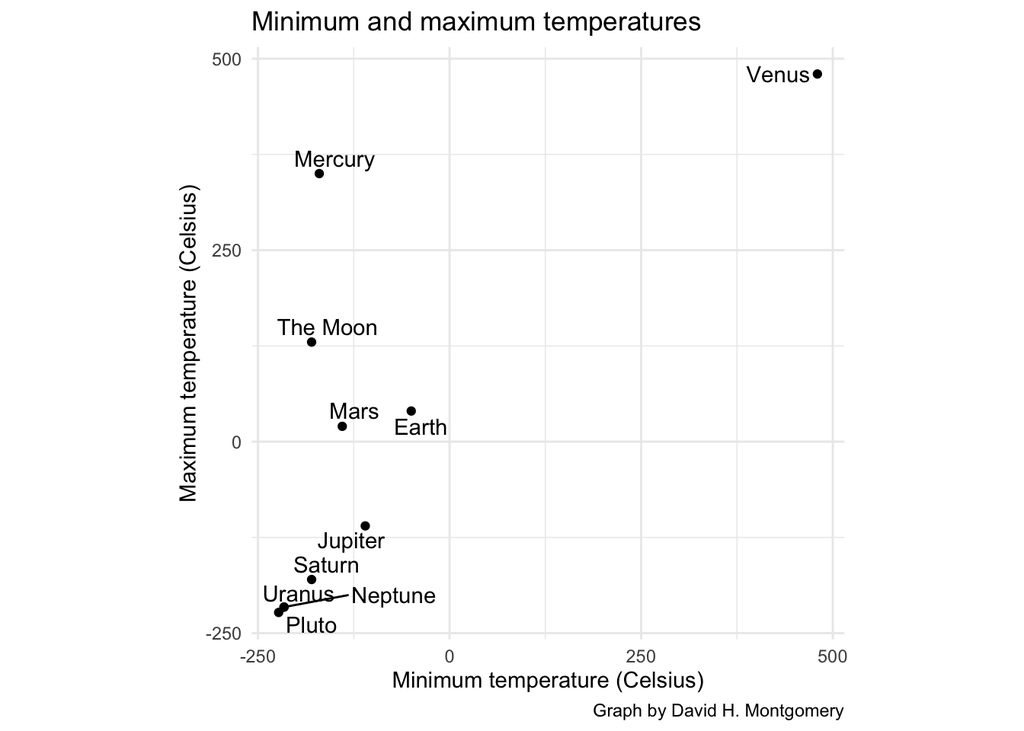

```r
space_data %>% # Start with our data
    # Make the chart
    ggplot(aes(x = temperature_min_c, # x = min temperature
               y = temperature_max_c)) + # y = max temperature
    geom_point() + # Make it a scatterplot
    geom_text_repel(aes(label = object)) + # Add labels, repelled away if they overlap
    theme_minimal() + # Set our theme
    coord_fixed(clip = "off") + # Fix coordinates, turn off clipping at the edge of the graph
    # Label chart
    labs(title = "Minimum and maximum temperatures",
         caption = "Graph by David H. Montgomery",
         x = "Minimum temperature (Celsius)",
         y = "Maximum temperature (Celsius)")
```

```r
ggsave("temperature.png", width = 7, height = 7) # Save to disk
```

## Learning more

Various R tutorials I’ve written:

- [R data analysis & visualization for beginners](https://github.com/dhmontgomery/r-data-for-beginners)
- [Gathering and cleaning data in R](https://github.com/dhmontgomery/nicar19/blob/master/r3.md)
- [Making graphics with R](https://github.com/dhmontgomery/nicar20/blob/master/ggplot-graphics/readme.md)

Hadley Wickham and Garrett Grolemund’s excellent free ebook, [R for Data Science](https://r4ds.had.co.nz/)

The video game [Kerbal Space Program](https://www.kerbalspaceprogram.com/)

CGP Grey’s video, [“Which Planet is Closest”](https://www.youtube.com/watch?v=SumDHcnCRuU):

[video not shown]